# Notebook

### Exercice 1

Écrivez un programme pour saisir deux nombres de l'utilisateur et calculer leur somme. L'utilisateur doit donc entrer deux valeurs, puis le programme calcule leur somme

Exemple :

*Données d'entrée*

- Saisir le premier nombre : 7
- Saisir le deuxième nombre : 8

*Données de sortie*

- La somme = 15

```python
#Solution
nb1=int(input('Saisir le premier nombre :'))
nb2=int(input('Saisir le deuxième nombre :'))
somme = nb1 + nb2
print("la somme = ", somme)
```

### Exercice 2

Écrivez un programme pour saisir la longueur et la largeur d'un rectangle et calculer son périmètre.

perimetre = 2(longueur+largeur)

Exemple :

*Données d'entrée*

- Saisir la longueur : 5
- Saisir la largeur : 10

*Données de sortie*

- le périmètre = 30

```python
#Solution
longueur=float(input('Saisir la longueur :'))
largeur=float(input('Saisir la largeur:'))
perimetre = 2 * (longueur + largeur)
print("le périmètre = ", perimetre)
```

### Exercice 3

Écrivez un programme pour saisir la longueur en centimètres et convertissez-le en mètres et en kilomètres.

Exemple :

*Données d'entrée*

- Saisir la longueur en centimètres : 1000

*Données de sortie*

- Longueur en mètres = 10 m
- Longueur en Kilomètres = 0.01 km

```python
#Solution
cm = float(input('Saisir la longueur en centimètres :'))
metre = cm / 100.0
km = cm / 100000.0
print("Longueur en mètres = {0} m".format(metre))
print("Longueur en Kilomètres = {0} km".format(km))
```

### Exercice 4

Écrivez un programme pour saisir le nombre de jours de l'utilisateur et convertissez-le en années, semaines et jours.

**Exemple :**

*Données d'entrée*

- Saisir le nombre de jours : 373

*Données de sortie*

- 1 an(s)
- 1 semaine(s)
- Jour(s) : 1 jour(s)

```python
#solution
jours = int(input('Saisir le nombre de jours : '))
annees = (jours // 365)
semaines = (jours % 365) // 7
jours = jours - ((annees * 365) + (semaines * 7))
print("{0} an(s) \n".format(annees))
print("{0} semaine(s) \n".format(semaines))
print("{0} jour(s)".format(jours))
```

### Exercice 5

Écrivez un programme pour saisir deux nombres de l'utilisateur et trouvez leur puissance.

Exemple :

*Données d'entrée*

- Saisir la base : 6
- Saisir l'exposant : 2

*Données de sortie*

- 6 ^ 2 = 36

```python
#solution
base = float(input('Saisir la base : '))
expo = float(input("Saisir l'exposant : "))
puissance = math.pow(base, expo)
print('{0} ^ {1} = {2}'.format(base, expo, puissance))
```

### Exercice 6

Écrivez un programme pour saisir un nombre et calculer sa racine carrée.

Exemple :

*Données d'entrée*

- Saisir un nombre : 9

*Données de sortie*

- La racine carrée du 9 = 3

```python
#solution
import math

nb = int(input('Saisir un nombre : '))
racine = math.sqrt(nb)
print("La racine carrée du {0} = {1}".format(nb, racine))
```

### Exercice 7

Écrivez un programme pour saisir deux angles de l'utilisateur et trouver le troisième angle du triangle.

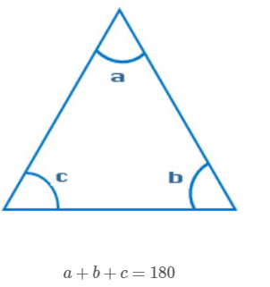

Exemple :

*Données d'entrée*

- Angles : 50 30

*Données de sortie*

- 3ème angle = 100

```python
#solution
a=int(input('Saisir angle 1'))
b=int(input('Saisir angle 2'))
c = 180 - (a + b)
print("3eme angle = ", c)
```

### Exercice 8

Écrivez un programme pour saisir la base et la hauteur d'un triangle et trouver la surface du triangle donné.

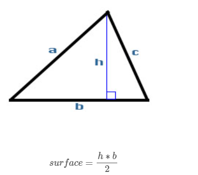

Exemple :

*Données d'entrée*

- Saisir la base : 15
- Saisir la hauteur : 30

*Données de sortie*

- La surface est = 225

```python
#solution
base = float(input('saisir la base : '))
hauteur = float(input('Saisir la hauteur : '))
surface = (base * hauteur) / 2
print("La surface est = ", surface)
```

### Exercice 9

Écrivez un programme pour saisir les notes de cinq matières d'un élève et calculer le total, la moyenne et le pourcentage de toutes les matières.

Exemple :

*Données d'entrée*

- Saisir les notes de 5 matières : 10 11 12 13 14

*Données de sortie*

- Total = 60
- Moyenne = 12
- Pourcentage = 12.00 %

```python
#solution
mat1 = float(input('Saisir la 1ere note : '))
mat2 = float(input('Saisir la 2eme note : '))
mat3 = float(input('Saisir la 3eme note : '))
mat4 = float(input('Saisir la 4eme note : '))
mat5 = float(input('Saisir la 5eme note : '))
total = mat1 + mat2 + mat3 + mat4 + mat5
moyenne = total / 5.0
pourcentage = (total / 500.0) * 100
print("Total = ", total)
print("Moyenne = ", moyenne)
print("Pourcentage = ", pourcentage)
```

### Exercice 10

Écrivez un programme pour saisir le côté d'un triangle équilatéral de l'utilisateur et trouvez la surface du triangle donné.

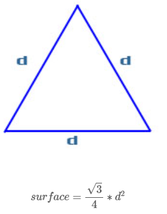

Exemple :

*Données d'entrée*

- Saisir le côté d'un triangle : 30

*Données de sortie*

- La surface du triangle = 389.71

```python
#solution
import math
cote = float(input("Saisir le cote d'un triangle :"))
surface = (math.sqrt(3) / 4) * (cote * cote)
print("La surface du triangle =  ", surface)
```